# Course Project 1

Load the data (i.e. read.csv()) Process/transform the data (if necessary) into a format suitable for your analysis

```r
dat <- read.csv("activity.csv", header = TRUE)
```

Calculate the total number of steps taken per day If you do not understand the difference between a histogram and a barplot, research the difference between them. Make a histogram of the total number of steps taken each day Calculate and report the mean and median of the total number of steps taken per day

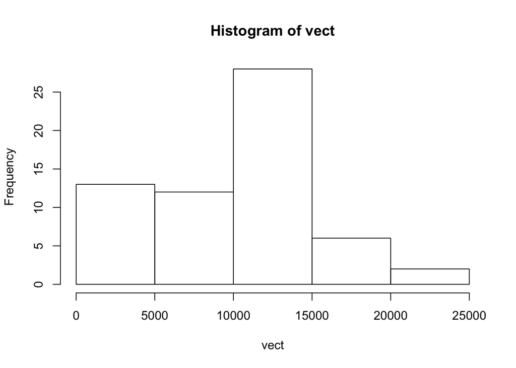

```r
dat<-na.omit(dat)
datsplit <- split(dat, f= dat$date)
vect <- numeric()
for(i in datsplit) vect <- append(vect, sum(i$steps))
hist(vect)
```

```r
mean(vect)
```

```
## [1] 9354.23
```

```r
median(vect)
```

```
## [1] 10395
```

Make a time series plot (i.e. type=“l”) of the 5-minute interval (x-axis) and the average number of steps taken, averaged across all days (y-axis) Which 5-minute interval, on average across all the days in the dataset, contains the maximum number of steps?

[figure not shown]

[output not shown]

```r
sum(is.na(dat))
```

```
## [1] 0
```

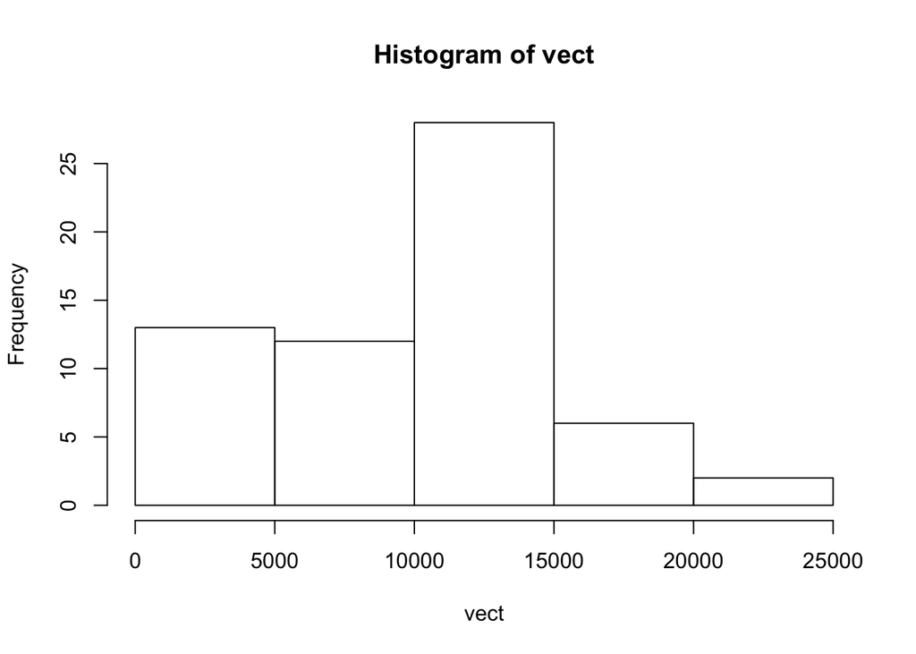

```r
fill.value <- function(steps, interval) {
    filled <- NA
    if (!is.na(steps))
        filled <- c(steps)
    else
        filled <- (averages[averages$interval==interval, "steps"])
    return(filled)
}
filled <- dat
filled$steps <- mapply(fill.value, filled$steps, filled$interval)
filledsplit <- split(filled, f= filled$date)
vect <- numeric()
for(i in filledsplit) vect <- c(vect, sum(i$steps))
hist(vect)
```

```r
mean(vect)
```

```
## [1] 9354.23
```

```r
median(vect)
```

```
## [1] 10395
```

Create a new factor variable in the dataset with two levels – “weekday” and “weekend” indicating whether a given date is a weekday or weekend day. Make a panel plot containing a time series plot (i.e. type=“l”) of the 5-minute interval (x-axis) and the average number of steps taken, averaged across all weekday days or weekend days (y-axis). See the README file in the GitHub repository to see an example of what this plot should look like using simulated data.

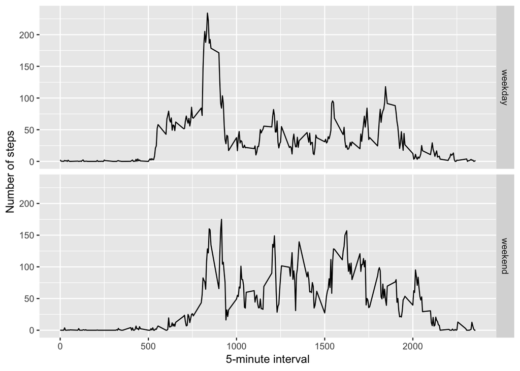

```r
weekday.or.weekend <- function(dat) {
    day <- weekdays(dat)
    if (day %in% c("Monday", "Tuesday", "Wednesday", "Thursday", "Friday"))
        return("weekday")
    else if (day %in% c("Saturday", "Sunday"))
        return("weekend")
    else
        stop("invalid date")
}
filled$date <- as.Date(filled$date)
filled$day <- sapply(filled$date, FUN=weekday.or.weekend)

averages <- aggregate(steps ~ interval + day, data=filled, mean)
ggplot(averages, aes(interval, steps)) + geom_line() + facet_grid(day ~ .) +
    xlab("5-minute interval") + ylab("Number of steps")
```